# Plant_Seedlings_Image_Classification_using_CNN_Project - Copy

## Plant Seedlings Image Classification using CNN Project

### Dataset Description

You are provided with a dataset of images of plant seedlings at various stages of grown. Each image has a filename that is its unique id. The dataset comprises 12 plant species. The goal of the project is to create a classifier capable of determining a plant's species from a photo.

**1. Import the libraries, load dataset, print shape of data, visualize the images in dataset. (5 Marks)**

```python
import tensorflow as tf
print(tf.__version__)
```

```
2.3.0
```

```python
import cv2
import math
import numpy as np
import pandas as pd
import matplotlib.pyplot as plt
import seaborn as sns
from tensorflow.keras import models, layers
from tensorflow.keras.optimizers import RMSprop, Adam
from keras.utils.np_utils import to_categorical # convert to one-hot-encoding
from sklearn.preprocessing import LabelBinarizer
from sklearn.model_selection import train_test_split
from sklearn.metrics import classification_report, confusion_matrix

import warnings
warnings.filterwarnings('ignore')

from IPython.core.display import display, HTML
display(HTML("<style>.container {width: 100% !important;} </style>"))
```

```python
from google.colab import drive
```

```python
drive.mount('/content/drive/')
```

```python
# Define the pathway to the folder where the csv and image files are stored
project_path = '/content/drive/My Drive/Colab Notebooks/'

dataset_file = project_path + 'Labels.csv'

dataset_file_2 = project_path + 'images.npy'
```

```python
# Reading the csv file
label = pd.read_csv(dataset_file)
```

```python
# Load the image file
images = np.load(dataset_file_2)
```

```python
# Analysis of the body of distributions / head
label.head()
```

|  | Label |
| --- | --- |
| 0 | Small-flowered Cranesbill |
| 1 | Small-flowered Cranesbill |
| 2 | Small-flowered Cranesbill |
| 3 | Small-flowered Cranesbill |
| 4 | Small-flowered Cranesbill |

```python
# Number of rows and columns
label.shape
```

```
(4750, 1)
```

```python
images.shape
```

```
(4750, 128, 128, 3)
```

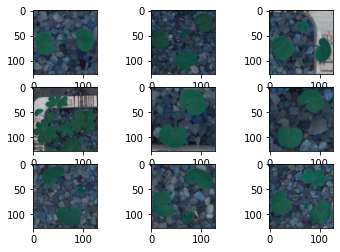

```python
# Plot images
for i in range(9):
    plt.subplot(3, 3, i + 1)
    plt.imshow(images[i])
```

**Other Basic Univariate analysis and EDA**

```python
# Missing values
label.isna().sum()
```

```
Label    0
dtype: int64
```

```python
# Taking value count of the missing values
label.isnull().apply(pd.value_counts)
```

|  | Label |
| --- | --- |
| False | 4750 |

```python
# Basic Information of the dataset including data types
label.info()
```

```
<class 'pandas.core.frame.DataFrame'>
RangeIndex: 4750 entries, 0 to 4749
Data columns (total 1 columns):
 #   Column  Non-Null Count  Dtype
---  ------  --------------  -----
 0   Label   4750 non-null   object
dtypes: object(1)
memory usage: 37.2+ KB
```

```python
# Outliers discovery using Interquartile range (IQR)
Q1 = label.quantile(0.25)
Q3 = label.quantile(0.75)
IQR = Q3-Q1
print(IQR)
```

```
Series([], dtype: float64)
```

```python
# Check number of zeros in the column
(label==0).sum()
```

```
Label    0
dtype: int64
```

```python
# Description of the independent attributes (name, range of values observed, mean and median, standard deviation and quartiles)
label.describe().transpose()
```

|  | count | unique | top | freq |
| --- | --- | --- | --- | --- |
| Label | 4750 | 12 | Loose Silky-bent | 654 |

```python
# Number of unique values in each column
label.nunique()
```

```
Label    12
dtype: int64
```

```python
#Check for duplicte rows
label.duplicated().sum()
```

```
4738
```

```python
# Skewness of the dataset
label.skew()
```

```
Series([], dtype: float64)
```

**2. Data Pre-processing: (15 Marks)**

a. Normalization.

b. Gaussian Blurring.

c. Visualize data after pre-processing.

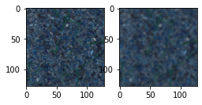

```python
# Initialize list for storage of images after pre-processing
prep_images = []
for img in images:
# Use Gaussian blurring
    blurImg = cv2.GaussianBlur(img, (5, 5), 0)


    prep_images.append(blurImg)


# Plot the original and blurred image
plt.subplot(1, 3, 1); plt.imshow(img)

plt.subplot(1, 3, 2); plt.imshow(blurImg)

# Convert to numpy array
prep_images = np.asarray(prep_images)
```

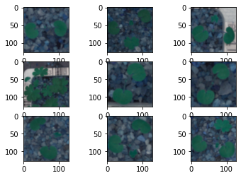

```python
for i in range(9):
    plt.subplot(3, 3, i + 1)
    plt.imshow(prep_images[i])
```

```python
# Normalize the image data
prep_images = prep_images / 255
```

**3. Make data compatible: (10 Marks)**

a. Convert labels to one-hot-vectors.

b. Print the label for y_train[0].

c. Split the dataset into training, testing, and validation set.

(Hint: First split images and labels into training and testing set with test_size = 0.3. Then further split test data into test and validation set with test_size = 0.5)

d. Check the shape of data, Reshape data into shapes compatible with Keras models if it’s not already. If it’s already in the compatible shape, then comment in the notebook that it’s already in compatible shape.

```python
# One hot vectors
enc = LabelBinarizer()
y = enc.fit_transform(label)
```

```python
# Print label for y_train
y[0]
```

```
array([0, 0, 0, 0, 0, 0, 0, 0, 0, 0, 1, 0])
```

```python
X_train, X_test, y_train, y_test = train_test_split(prep_images, y, test_size=0.3, random_state=50)
```

```python
X_train.shape
```

```
(3325, 128, 128, 3)
```

```python
y_train.shape
```

```
(3325, 12)
```

```python
X_test.shape
```

```
(1425, 128, 128, 3)
```

```python
y_test.shape
```

```
(1425, 12)
```

```python
# Reshape data to enable compatibility with Keras models
X_train = X_train.reshape(X_train.shape[0], 128, 128, 3)
X_test = X_test.reshape(X_test.shape[0], 128, 128, 3)
```

```python
X_train.shape
```

```
(3325, 128, 128, 3)
```

```python
y_train.shape
```

```
(3325, 12)
```

```python
X_test.shape
```

```
(1425, 128, 128, 3)
```

```python
y_test.shape
```

```
(1425, 12)
```

Please note that there is no change in the two shapes above indicating compatibility with Keras

```python
random_seed = 2
X_test, X_val, y_test, Y_val = train_test_split(X_test, y_test, test_size = 0.5, random_state=random_seed)
```

```python
X_test.shape
```

```
(712, 128, 128, 3)
```

```python
X_val.shape
```

```
(713, 128, 128, 3)
```

**4. Building CNN: (15 Marks)**

a. Define layers.

b. Set optimizer and loss function. (Use Adam optimizer and categorical crossentropy.)

```python
# Define Layers
batch_size = None

model = models.Sequential()
model.add(layers.Conv2D(32, (5, 5), padding='same', activation="relu", input_shape=(128, 128, 3)))
model.add(layers.BatchNormalization())
model.add(layers.MaxPooling2D((2, 2)))
model.add(layers.Dropout(0.2))
model.add(layers.Conv2D(64, (5, 5), padding='same', activation="relu"))
model.add(layers.BatchNormalization())
model.add(layers.MaxPooling2D((2, 2)))
model.add(layers.Dropout(0.3))
model.add(layers.Conv2D(64, (3, 3), padding='same', activation="relu"))
model.add(layers.BatchNormalization())
model.add(layers.MaxPooling2D((2, 2)))
model.add(layers.Dropout(0.4))
model.add(layers.Conv2D(64, (3, 3), padding='same', activation="relu"))
model.add(layers.BatchNormalization())
model.add(layers.MaxPooling2D((2, 2)))
model.add(layers.Dropout(0.5))

model.add(layers.GlobalMaxPooling2D())
model.add(layers.Dense(256, activation="relu"))
model.add(layers.Dropout(0.5))
model.add(layers.Dense(12, activation="softmax"))

model.summary()
```

```
Model: "sequential_2"
_________________________________________________________________
Layer (type)                 Output Shape              Param #
=================================================================
conv2d_8 (Conv2D)            (None, 128, 128, 32)      2432
_________________________________________________________________
batch_normalization_8 (Batch (None, 128, 128, 32)      128
_________________________________________________________________
max_pooling2d_8 (MaxPooling2 (None, 64, 64, 32)        0
_________________________________________________________________
dropout_10 (Dropout)         (None, 64, 64, 32)        0
_________________________________________________________________
conv2d_9 (Conv2D)            (None, 64, 64, 64)        51264
_________________________________________________________________
batch_normalization_9 (Batch (None, 64, 64, 64)        256
_________________________________________________________________
max_pooling2d_9 (MaxPooling2 (None, 32, 32, 64)        0
_________________________________________________________________
dropout_11 (Dropout)         (None, 32, 32, 64)        0
_________________________________________________________________
conv2d_10 (Conv2D)           (None, 32, 32, 64)        36928
_________________________________________________________________
batch_normalization_10 (Batc (None, 32, 32, 64)        256
_________________________________________________________________
max_pooling2d_10 (MaxPooling (None, 16, 16, 64)        0
_________________________________________________________________
dropout_12 (Dropout)         (None, 16, 16, 64)        0
_________________________________________________________________
conv2d_11 (Conv2D)           (None, 16, 16, 64)        36928
_________________________________________________________________
batch_normalization_11 (Batc (None, 16, 16, 64)        256
_________________________________________________________________
max_pooling2d_11 (MaxPooling (None, 8, 8, 64)          0
_________________________________________________________________
dropout_13 (Dropout)         (None, 8, 8, 64)          0
_________________________________________________________________
global_max_pooling2d_2 (Glob (None, 64)                0
_________________________________________________________________
dense_4 (Dense)              (None, 256)               16640
_________________________________________________________________
dropout_14 (Dropout)         (None, 256)               0
_________________________________________________________________
dense_5 (Dense)              (None, 12)                3084
=================================================================
Total params: 148,172
Trainable params: 147,724
Non-trainable params: 448
_________________________________________________________________
```

```python
# Set the optimizer and loss function
optimizer = Adam( learning_rate=0.001,
                  beta_1=0.9,
                  beta_2=0.999,
                  epsilon=1e-07,
                  amsgrad=False,
                  name='Adam')
model.compile(optimizer = optimizer, loss="categorical_crossentropy", metrics = ["accuracy"])
```

**5. Fit and evaluate model and print confusion matrix. (10 Marks)**

```python
# Set epochs = 55
# Fit the model
history = model.fit(X_train, y_train, epochs = 55, validation_data = (X_val,Y_val), batch_size = batch_size)
```

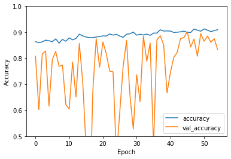

```python
plt.plot(history.history['accuracy'], label='accuracy')
plt.plot(history.history['val_accuracy'], label = 'val_accuracy')
plt.xlabel('Epoch')
plt.ylabel('Accuracy')
plt.ylim([0.5, 1])
plt.legend(loc='lower right');
```

```python
# Model evaluation
score = model.evaluate(X_test, y_test, verbose=1)
print('Test loss:', score[0])
print('Test accuracy:', score[1])
```

```
Test loss: 0.4836161434650421
Test accuracy: 0.8384831547737122
```

```python
Y_pred = model.predict(X_val)
result = np.argmax(Y_pred, axis=1)
Y_true = np.argmax(Y_val, axis=1)

mat = confusion_matrix(Y_true, result)
```

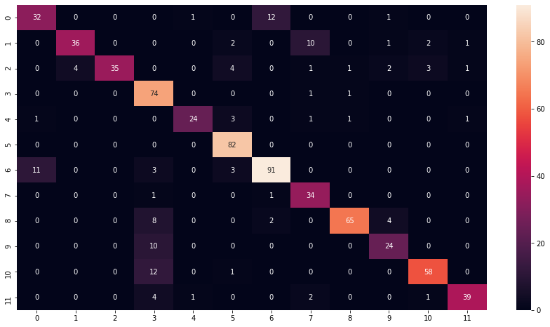

```python
cm = pd.DataFrame(mat, index = [i for i in range(0, 12)],
                  columns = [i for i in range(0, 12)])
plt.figure(figsize = (15,8))
sns.heatmap(cm, annot=True, fmt='g');
```

**6. Visualize predictions for x_test[2], x_test[3], x_test[33], x_test[36], x_test[59]. (5 Marks)**

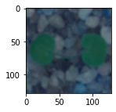

```
Predicted_label 10
True_label 10
```

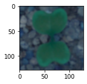

```
Predicted_label 7
True_label 1
```

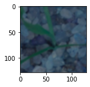

```
Predicted_label 8
True_label 6
```

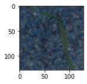

```
Predicted_label 4
True_label 4
```

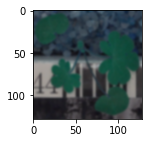

```
Predicted_label 10
True_label 10
```

```python
plt.figure(figsize=(2,2))
plt.imshow(X_test[2],cmap="gray")
plt.show()
print('Predicted_label', np.argmax(model.predict(X_test[2].reshape(1,128,128,3))))
print('True_label', np.argmax(y_test[2]))

plt.figure(figsize=(2,2))
plt.imshow(X_test[3],cmap="gray")
plt.show()
print('Predicted_label', np.argmax(model.predict(X_test[3].reshape(1,128,128,3))))
print('True_label', np.argmax(y_test[3]))

plt.figure(figsize=(2,2))
plt.imshow(X_test[33],cmap="gray")
plt.show()
print('Predicted_label', np.argmax(model.predict(X_test[33].reshape(1,128,128,3))))
print('True_label', np.argmax(y_test[33]))

plt.figure(figsize=(2,2))
plt.imshow(X_test[59],cmap="gray")
plt.show()
print('Predicted_label', np.argmax(model.predict(X_test[59].reshape(1,128,128,3))))
print('True_label', np.argmax(y_test[59]))

plt.figure(figsize=(2,2))
plt.imshow(X_test[36],cmap="gray")
plt.show()
print('Predicted_label', np.argmax(model.predict(X_test[36].reshape(1,128,128,3))))
print('True_label', np.argmax(y_test[36]))
```